# Assignment1

Myoung Hoon Lee

2019년 3월 24일

## 1. Introduction

### 분석목적

- 시장 선행 데이터와 시계열 기상 데이터를 이용하여 미세먼지 농도 및 종합 대기 환경에 대한 예측하고자 한다.
- 이를 통해서 공기청정기, 미세 먼지 필터 제조 업체 등 관련 사업에 수요 예측및 시장 상황에 대한 인사이트를 제공

```r
dim(weather)
```

```
## [1] 1538   33
```

```r
summary(weather)
```

```
##       date               평균기온         최저기온         최고기온
##  Min.   :2015-01-01   Min.   :-14.80   Min.   :-18.00   Min.   :-10.70
##  1st Qu.:2016-01-20   1st Qu.:  2.80   1st Qu.: -1.10   1st Qu.:  7.70
##  Median :2017-02-07   Median : 13.75   Median :  9.20   Median : 19.30
##  Mean   :2017-02-07   Mean   : 12.74   Mean   :  8.54   Mean   : 17.77
##  3rd Qu.:2018-02-26   3rd Qu.: 22.50   3rd Qu.: 18.20   3rd Qu.: 27.80
##  Max.   :2019-03-18   Max.   : 33.70   Max.   : 30.30   Max.   : 39.60
##                                                         NA's   :1
##  강수.계속시간       일강수량       최대.순간.풍속   최대.순간.풍속.풍향
##  Min.   : 0.070   Min.   :  0.000   Min.   : 3.900   Min.   : 20.0
##  1st Qu.: 1.580   1st Qu.:  0.100   1st Qu.: 6.700   1st Qu.:180.0
##  Median : 3.750   Median :  1.000   Median : 8.000   Median :270.0
##  Mean   : 5.614   Mean   :  7.715   Mean   : 8.292   Mean   :228.6
##  3rd Qu.: 8.250   3rd Qu.:  6.000   3rd Qu.: 9.500   3rd Qu.:290.0
##  Max.   :24.000   Max.   :144.500   Max.   :18.000   Max.   :360.0
##  NA's   :977      NA's   :977       NA's   :2        NA's   :2
##    최대.풍속      최대.풍속.풍향    평균.풍속         풍정합
##  Min.   : 1.600   Min.   : 20.0   Min.   :0.700   Min.   : 592
##  1st Qu.: 3.800   1st Qu.:200.0   1st Qu.:1.600   1st Qu.:1423
##  Median : 4.600   Median :270.0   Median :2.100   Median :1783
##  Mean   : 4.756   Mean   :238.6   Mean   :2.204   Mean   :1904
##  3rd Qu.: 5.600   3rd Qu.:290.0   3rd Qu.:2.600   3rd Qu.:2272
##  Max.   :11.100   Max.   :360.0   Max.   :6.400   Max.   :5505
##  NA's   :2        NA's   :2       NA's   :3       NA's   :2
##  평균.이슬점온도   최소.상대습도   평균.상대습도    평균.증기압
##  Min.   :-27.600   Min.   : 7.00   Min.   :21.80   Min.   : 0.70
##  1st Qu.: -5.800   1st Qu.:25.00   1st Qu.:46.83   1st Qu.: 4.10
##  Median :  4.550   Median :33.00   Median :57.90   Median : 8.60
##  Mean   :  3.825   Mean   :36.08   Mean   :57.96   Mean   :10.84
##  3rd Qu.: 14.000   3rd Qu.:45.00   3rd Qu.:68.00   3rd Qu.:16.10
##  Max.   : 25.000   Max.   :91.00   Max.   :97.30   Max.   :31.70
##                    NA's   :1
##  평균.현지기압  합계.일조.시간   시간당.최다일사량   합계.일사
##  Min.   : 981   Min.   : 0.000   Min.   :0.100     Min.   : 0.02
##  1st Qu.:1000   1st Qu.: 3.800   1st Qu.:1.413     1st Qu.: 7.68
##  Median :1007   Median : 8.300   Median :1.980     Median :12.02
##  Mean   :1007   Mean   : 7.057   Mean   :1.956     Mean   :12.83
##  3rd Qu.:1013   3rd Qu.: 9.900   3rd Qu.:2.590     3rd Qu.:17.78
##  Max.   :1027   Max.   :13.700   Max.   :3.520     Max.   :29.20
##                 NA's   :9        NA's   :8         NA's   :10
```

[output cut: 17 more lines]

```
##  Min.   :0.001000   나쁨     : 158   Min.   : 22.00
##  1st Qu.:0.003000   매우 나쁨:   6   1st Qu.: 53.00
##  Median :0.004000   보통     :1094   Median : 65.00
##  Mean   :0.004362   좋음     : 280   Mean   : 73.61
##  3rd Qu.:0.005000                    3rd Qu.: 82.00
##  Max.   :0.014000                    Max.   :468.00
##  NA's   :4
##              주오염물질    china_PM25
##  미세먼지(PM10)   :139   Min.   :  6.90
##  오존             :258   1st Qu.: 35.60
##  이산화질소       :630   Median : 60.60
##  초미세먼지(PM2.5):511   Mean   : 76.53
##                          3rd Qu.: 97.20
##                          Max.   :464.20
##                          NA's   :33
```

```r
str(weather)
```

```
## 'data.frame':    1538 obs. of  33 variables:
##  $ date               : Date, format: "2015-01-01" "2015-01-02" ...
##  $ 평균기온           : num  -7.7 -6 -2.7 2.5 3.7 -3.2 -5.5 -5.1 -2.1 -0.3 ...
##  $ 최저기온           : num  -9.8 -9 -9.2 0.2 -1.1 -7.6 -8.9 -9.5 -6.8 -5.6 ...
##  $ 최고기온           : num  -4.3 -1.9 3.1 8.5 7.9 4 -0.6 -0.2 3.5 4.8 ...
##  $ 강수.계속시간      : num  NA NA NA 0.08 3.83 3.67 NA NA NA NA ...
##  $ 일강수량           : num  NA NA NA 0 0.4 3 NA NA NA NA ...
##  $ 최대.순간.풍속     : num  12.1 13 6.7 6.1 6.9 10.9 6.8 6.7 7.1 9.5 ...
##  $ 최대.순간.풍속.풍향: num  270 270 250 70 70 270 270 230 250 270 ...
##  $ 최대.풍속          : num  6.5 6.7 4.4 3.7 4.4 7.3 4.5 4.8 4.2 6.3 ...
##  $ 최대.풍속.풍향     : num  320 290 230 50 70 290 320 270 290 270 ...
##  $ 평균.풍속          : num  4.6 3.2 1.9 2 2.4 4.3 2.5 2.2 2 2.3 ...
##  $ 풍정합             : num  3999 2789 1678 1758 2087 ...
##  $ 평균.이슬점온도    : num  -18.8 -16.1 -10.5 -2.5 -1 -12.4 -19.4 -15.4 -9.4 -8.2 ...
##  $ 최소.상대습도      : num  29 28 35 54 51 27 23 25 37 32 ...
```

[output cut: 19 more lines]

### 자료 구조 변경

- 변수 설명
- PM10 : 서울 중구 측정소에서 관측한 PM10($\mu$g/$m^2$)
- PM2.5 : 서울 중구 측정소에서 관측한 PM25($\mu$g/$m^2$)
- O3 : 서울 중구 측정소에서 관측한 오존($ppm$)
- NO2 :서울 중구 측정소에서 관측한 이산화질소($ppm$)
- CO : 서울 중구 측정소에서 관측한 일산화탄소($ppm$)
- SO2 : 서울 중구 측정소에서 관측한 아황산가스($ppm$)
- 종합대기상태 : CAI를 기준으로한 종합대기 상태(좋음, 보통, 나쁨, 매우 나쁨)
- 종합대기지수 : 통합대기환경지수(CAI, Comprehensive air-quality index)
- 주오염물질 : 통합 대기 환경 지수 계산 과정에서 대기환경에 가장 많은 영향을 주는 오염물질
- china_PM25 : 중국 베이징 관측소에서 관측한 PM25 농도

```r
# factor 변수 factor화 최대.풍속.풍향, 최대.풍속.풍향(16 방)
weather$최대.순간.풍속.풍향 <- as.factor(weather$최대.순간.풍속.풍향)
weather$최대.풍속.풍향 <- as.factor(weather$최대.풍속.풍향)

levels(weather$최대.순간.풍속.풍향)
```

```
##  [1] "20"  "50"  "70"  "90"  "110" "140" "160" "180" "200" "230" "250"
## [12] "270" "290" "320" "340" "360"
```

```r
levels(weather$최대.풍속.풍향)
```

```
##  [1] "20"  "50"  "70"  "90"  "110" "140" "160" "180" "200" "230" "250"
## [12] "270" "290" "320" "340" "360"
```

```r
# 풍정합 일정시간내에 이동한 공기의 취주거
# 결측치 제거(강수나 적설량은 결측치를 0으로 바꿈
```

## 2. Data Manipulation

### 결측치 제거

- 우선 기본적으로 관측치가 없는 강수량, 적설량 등의 데이터를 0으로 처리

```r
weather[which(is.na(weather$강수.계속시간)), '강수.계속시간'] <- 0
weather[which(is.na(weather$일강수량)), '일강수량'] <- 0
weather[which(is.na(weather$일.최심적설)), '일.최심적설'] <- 0
weather[which(is.na(weather$합계.대형증발량)), '합계.대형증발량'] <- 0
weather[which(is.na(weather$안개.계속시간)), '안개.계속시간'] <- 0
summary(weather)
```

```
##       date               평균기온         최저기온         최고기온
##  Min.   :2015-01-01   Min.   :-14.80   Min.   :-18.00   Min.   :-10.70
##  1st Qu.:2016-01-20   1st Qu.:  2.80   1st Qu.: -1.10   1st Qu.:  7.70
##  Median :2017-02-07   Median : 13.75   Median :  9.20   Median : 19.30
##  Mean   :2017-02-07   Mean   : 12.74   Mean   :  8.54   Mean   : 17.77
##  3rd Qu.:2018-02-26   3rd Qu.: 22.50   3rd Qu.: 18.20   3rd Qu.: 27.80
##  Max.   :2019-03-18   Max.   : 33.70   Max.   : 30.30   Max.   : 39.60
##                                                         NA's   :1
##  강수.계속시간       일강수량       최대.순간.풍속   최대.순간.풍속.풍향
##  Min.   : 0.000   Min.   :  0.000   Min.   : 3.900   270    :266
##  1st Qu.: 0.000   1st Qu.:  0.000   1st Qu.: 6.700   290    :262
##  Median : 0.000   Median :  0.000   Median : 8.000   320    :188
##  Mean   : 2.048   Mean   :  2.814   Mean   : 8.292   250    :142
##  3rd Qu.: 2.042   3rd Qu.:  0.200   3rd Qu.: 9.500   50     : 96
##  Max.   :24.000   Max.   :144.500   Max.   :18.000   (Other):582
##                                     NA's   :2        NA's   :  2
##    최대.풍속      최대.풍속.풍향   평균.풍속         풍정합
##  Min.   : 1.600   270    :327    Min.   :0.700   Min.   : 592
##  1st Qu.: 3.800   290    :313    1st Qu.:1.600   1st Qu.:1423
##  Median : 4.600   320    :195    Median :2.100   Median :1783
##  Mean   : 4.756   250    :110    Mean   :2.204   Mean   :1904
##  3rd Qu.: 5.600   70     :109    3rd Qu.:2.600   3rd Qu.:2272
##  Max.   :11.100   (Other):482    Max.   :6.400   Max.   :5505
##  NA's   :2        NA's   :  2    NA's   :3       NA's   :2
##  평균.이슬점온도   최소.상대습도   평균.상대습도    평균.증기압
##  Min.   :-27.600   Min.   : 7.00   Min.   :21.80   Min.   : 0.70
##  1st Qu.: -5.800   1st Qu.:25.00   1st Qu.:46.83   1st Qu.: 4.10
##  Median :  4.550   Median :33.00   Median :57.90   Median : 8.60
##  Mean   :  3.825   Mean   :36.08   Mean   :57.96   Mean   :10.84
##  3rd Qu.: 14.000   3rd Qu.:45.00   3rd Qu.:68.00   3rd Qu.:16.10
##  Max.   : 25.000   Max.   :91.00   Max.   :97.30   Max.   :31.70
##                    NA's   :1
##  평균.현지기압  합계.일조.시간   시간당.최다일사량   합계.일사
##  Min.   : 981   Min.   : 0.000   Min.   :0.100     Min.   : 0.02
##  1st Qu.:1000   1st Qu.: 3.800   1st Qu.:1.413     1st Qu.: 7.68
##  Median :1007   Median : 8.300   Median :1.980     Median :12.02
##  Mean   :1007   Mean   : 7.057   Mean   :1.956     Mean   :12.83
##  3rd Qu.:1013   3rd Qu.: 9.900   3rd Qu.:2.590     3rd Qu.:17.78
##  Max.   :1027   Max.   :13.700   Max.   :3.520     Max.   :29.20
##                 NA's   :9        NA's   :8         NA's   :10
```

[output cut: 17 more lines]

```
##  Min.   :0.001000   나쁨     : 158   Min.   : 22.00
##  1st Qu.:0.003000   매우 나쁨:   6   1st Qu.: 53.00
##  Median :0.004000   보통     :1094   Median : 65.00
##  Mean   :0.004362   좋음     : 280   Mean   : 73.61
##  3rd Qu.:0.005000                    3rd Qu.: 82.00
##  Max.   :0.014000                    Max.   :468.00
##  NA's   :4
##              주오염물질    china_PM25
##  미세먼지(PM10)   :139   Min.   :  6.90
##  오존             :258   1st Qu.: 35.60
##  이산화질소       :630   Median : 60.60
##  초미세먼지(PM2.5):511   Mean   : 76.53
##                          3rd Qu.: 97.20
##                          Max.   :464.20
##                          NA's   :33
```

```r
weather$months <- as.factor(months((weather$date)))
weather$years <-  as.factor(substr(weather$date, 1,4))
weather$months <- factor(weather$months, levels = c("1월", "2월",  "3월",  "4월",  "5월",  "6월",  "7월",  "8월",  "9월", "10월", "11월", "12월"))
```

- 나머지 결측치에 대해서는 연월별 평균 값으로 대체

```r
# 최고기온
mean_max_temp <- weather %>% group_by(years,months) %>% summarise(Max_temp_mean = mean(최고기온, na.rm = TRUE))
weather[which(is.na(weather$최고기온)), '최고기온'] <- as.vector(unlist(mean_max_temp[which(mean_max_temp$years == 2017 & mean_max_temp$months == "10월"), 'Max_temp_mean']))


# 최대 순간 풍속
mean_max_m_ws <- weather %>% group_by(years,months) %>% summarise(ws_m_mean = mean(최대.순간.풍속, na.rm = TRUE))
numofNA <- dim(weather[which(is.na(weather$최대.순간.풍속)), c('date', '최대.순간.풍속')])[1]
for (i in seq(numofNA)) {
  year <- as.character(weather[which(is.na(weather$최대.순간.풍속)), c('years','months', '최대.순간.풍속')][1,1])
  month <- as.character(weather[which(is.na(weather$최대.순간.풍속)), c('years','months', '최대.순간.풍속')][1,2])
  weather[which(is.na(weather$최대.순간.풍속)), '최대.순간.풍속'][1] <- as.vector(unlist(mean_max_m_ws[which(mean_max_m_ws$years == year & mean_max_m_ws$months == month), 'ws_m_mean']))
}

#최대 풍속
mean_max_ws <- weather %>% group_by(years,months) %>% summarise(ws_mean = mean(최대.풍속, na.rm = TRUE))
numofNA <- dim(weather[which(is.na(weather$최대.풍속)), c('date', '최대.풍속')])[1]
for (i in seq(numofNA)) {
  year <- weather[which(is.na(weather$최대.풍속)), c('years','months', '최대.풍속')][1,1]
  month <- weather[which(is.na(weather$최대.풍속)), c('years','months', '최대.풍속')][1,2]
  weather[which(is.na(weather$최대.풍속)), '최대.풍속'][1]  <- as.vector(unlist(mean_max_ws[which(mean_max_ws$years == year & mean_max_ws$months == month), 'ws_mean']))
}

mean_avg_ws <- weather %>% group_by(years,months) %>% summarise(ws_avg_mean = mean(평균.풍속, na.rm = TRUE))
numofNA <- dim(weather[which(is.na(weather$평균.풍속)), c('date', '평균.풍속')])[1]
for (i in seq(numofNA)) {
  year <- weather[which(is.na(weather$평균.풍속)), c('years','months', '평균.풍속')][1,1]
  month <- weather[which(is.na(weather$평균.풍속)), c('years','months', '평균.풍속')][1,2]
  weather[which(is.na(weather$평균.풍속)), '평균.풍속'][1]  <- as.vector(unlist(mean_avg_ws[which(mean_avg_ws$years == year & mean_avg_ws$months == month), 'ws_avg_mean']))
}

mean_wind_watch <- weather %>% group_by(years,months) %>% summarise(ww_mean = mean(풍정합, na.rm = TRUE))
numofNA <- dim(weather[which(is.na(weather$풍정합)), c('date', '풍정합')])[1]
for (i in seq(numofNA)) {
  year <- weather[which(is.na(weather$풍정합)), c('years','months', '풍정합')][1,1]
  month <- weather[which(is.na(weather$풍정합)), c('years','months', '풍정합')][1,2]
  weather[which(is.na(weather$풍정합)), '풍정합'][1]  <- as.vector(unlist(mean_wind_watch[which(mean_wind_watch$years == year & mean_wind_watch$months == month), 'ww_mean']))
}

#평균이슬점
mean_avg_dt <- weather %>% group_by(years,months) %>% summarise(avg_dt = mean(평균.이슬점온도, na.rm = TRUE))
numofNA <- dim(weather[which(is.na(weather$평균.이슬점온도)), c('date', '평균.이슬점온도')])[1]
for (i in seq(numofNA)) {
  year <- weather[which(is.na(weather$평균.이슬점온도)), c('years','months', '평균.이슬점온도')][1,1]
  month <- weather[which(is.na(weather$평균.이슬점온도)), c('years','months', '평균.이슬점온도')][1,2]
  weather[which(is.na(weather$평균.이슬점온도)), '평균.이슬점온도'][1]  <- as.vector(unlist(mean_avg_dt[which(mean_avg_dt$years == year & mean_avg_dt$months == month), 'avg_dt']))
}

min_humidity <- weather %>% group_by(years,months) %>% summarise(min_rh = mean(최소.상대습도, na.rm = TRUE))
numofNA <- dim(weather[which(is.na(weather$최소.상대습도)), c('date', '최소.상대습도')])[1]
for (i in seq(numofNA)) {
  year <- weather[which(is.na(weather$최소.상대습도)), c('years','months', '최소.상대습도')][1,1]
  month <- weather[which(is.na(weather$최소.상대습도)), c('years','months', '최소.상대습도')][1,2]
  weather[which(is.na(weather$최소.상대습도)), '최소.상대습도'][1]  <- as.vector(unlist(min_humidity[which(min_humidity$years == year & min_humidity$months == month), 'min_rh']))
}

sum_sh <- weather %>% group_by(years,months) %>% summarise(sum_sh = mean(합계.일조.시간, na.rm = TRUE))
numofNA <- dim(weather[which(is.na(weather$합계.일조.시간)), c('date', '합계.일조.시간')])[1]
for (i in seq(numofNA)) {
  year <- weather[which(is.na(weather$합계.일조.시간)), c('years','months', '합계.일조.시간')][1,1]
  month <- weather[which(is.na(weather$합계.일조.시간)), c('years','months', '합계.일조.시간')][1,2]
  weather[which(is.na(weather$합계.일조.시간)), '합계.일조.시간'][1]  <- as.vector(unlist(sum_sh[which(sum_sh$years == year & sum_sh$months == month), 'sum_sh']))
}

#시간당.최다일사량
timely_max_irradiation  <- weather %>% group_by(years,months) %>% summarise(t_max_i = mean(시간당.최다일사량, na.rm = TRUE))
numofNA <- dim(weather[which(is.na(weather$시간당.최다일사량)), c('date', '시간당.최다일사량')])[1]
for (i in seq(numofNA)) {
  year <- weather[which(is.na(weather$시간당.최다일사량)), c('years','months', '시간당.최다일사량')][1,1]
  month <- weather[which(is.na(weather$시간당.최다일사량)), c('years','months', '시간당.최다일사량')][1,2]
  weather[which(is.na(weather$시간당.최다일사량)), '시간당.최다일사량'][1]  <- as.vector(unlist(timely_max_irradiation[which(timely_max_irradiation$years == year & timely_max_irradiation$months == month), 't_max_i']))
}

#합계.일사
sum_irradiation  <- weather %>% group_by(years,months) %>% summarise(sum_irr = mean(합계.일사, na.rm = TRUE))
numofNA <- dim(weather[which(is.na(weather$합계.일사)), c('date', '풍정합')])[1]
for (i in seq(numofNA)) {
  year <- weather[which(is.na(weather$합계.일사)), c('years','months', '합계.일사')][1,1]
  month <- weather[which(is.na(weather$합계.일사)), c('years','months', '합계.일사')][1,2]
  weather[which(is.na(weather$합계.일사)), '합계.일사'][1]  <- as.vector(unlist(sum_irradiation[which(sum_irradiation$years == year & sum_irradiation$months == month), 'sum_irr']))
}

group_NO2 <- weather %>% group_by(years,months) %>% summarise(no2 = mean(NO2, na.rm = TRUE))
numofNA <- dim(weather[which(is.na(weather$NO2)), c('date', 'NO2')])[1]
for (i in seq(numofNA)) {
  year <- weather[which(is.na(weather$NO2)), c('years','months', 'NO2')][1,1]
  month <- weather[which(is.na(weather$NO2)), c('years','months', 'NO2')][1,2]
  weather[which(is.na(weather$NO2)), 'NO2'][1]  <- as.vector(unlist(group_NO2[which(group_NO2$years == year & group_NO2$months == month), 'no2']))
}

group_CO <- weather %>% group_by(years,months) %>% summarise(co = mean(CO, na.rm = TRUE))
numofNA <- dim(weather[which(is.na(weather$CO)), c('date', 'CO')])[1]
for (i in seq(numofNA)) {
  year <- weather[which(is.na(weather$CO)), c('years','months', 'CO')][1,1]
  month <- weather[which(is.na(weather$CO)), c('years','months', 'CO')][1,2]
  weather[which(is.na(weather$CO)), 'CO'][1]  <- as.vector(unlist(group_CO[which(group_CO$years == year & group_CO$months == month), 'co']))
}

group_SO2 <- weather %>% group_by(years,months) %>% summarise(so2 = mean(SO2, na.rm = TRUE))
numofNA <- dim(weather[which(is.na(weather$SO2)), c('date', 'SO2')])[1]
for (i in seq(numofNA)) {
  year <- weather[which(is.na(weather$SO2)), c('years','months', 'SO2')][1,1]
  month <- weather[which(is.na(weather$SO2)), c('years','months', 'SO2')][1,2]
  weather[which(is.na(weather$SO2)), 'SO2'][1]  <- as.vector(unlist(group_SO2[which(group_SO2$years == year & group_SO2$months == month), 'so2']))
}

group_china <- weather %>% group_by(years, months) %>% summarise(china_dust = median(china_PM25, na.rm=TRUE))
numofNA <- dim(weather[which(is.na(weather$china_PM25)), c('date', 'china_PM25')])[1]
for (i in seq(numofNA)) {
  year <- weather[which(is.na(weather$china_PM25)), c('years','months', 'china_PM25')][1,1]
  month <- weather[which(is.na(weather$china_PM25)), c('years','months', 'china_PM25')][1,2]
  weather[which(is.na(weather$china_PM25)), 'china_PM25'][1]  <- as.vector(unlist(group_china[which(group_china$years == year & group_china$months == month), 'china_dust']))
}
```

### 풍향 별 대기 환경 요약 및 풍향 결측치 제거

```r
length(levels(weather$최대.풍속.풍향))
```

```
## [1] 16
```

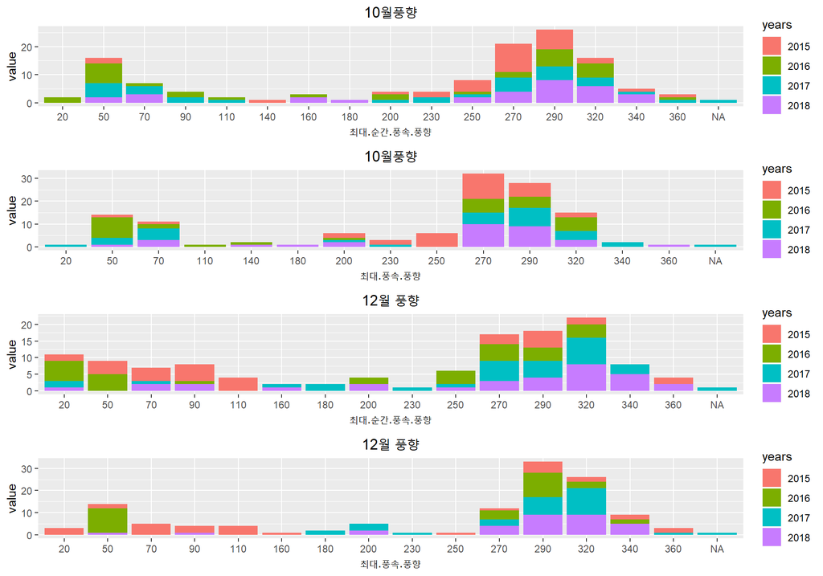

```r
group_direction1 <- weather %>% group_by(years,months, 최대.순간.풍속.풍향) %>% summarise(count = n())
group_direction1 <- as.data.frame(group_direction1)

group_direction2 <- weather %>% group_by(years,months, 최대.풍속.풍향) %>% summarise(count = n())
group_direction2 <- as.data.frame(group_direction2)
colnames(group_direction1)[4] <- "value"
colnames(group_direction2)[4] <- "value"
d1 <- ggplot(group_direction1[which(group_direction1$months == "10월"),], aes(x=factor(최대.순간.풍속.풍향), y=value, fill=years)) +
  geom_bar(stat = "identity") + ggtitle("10월풍향") +
  theme(plot.title = element_text(hjust = 0.5)) +
  xlab("최대.순간.풍속.풍향")

d2 <- ggplot(group_direction2[which(group_direction2$months == "10월"),], aes(x=factor(최대.풍속.풍향), y=value, fill=years)) +
  geom_bar(stat = "identity") + ggtitle("10월풍향") +
  theme(plot.title = element_text(hjust = 0.5)) +
  xlab("최대.풍속.풍향")

d3 <- ggplot(group_direction1[which(group_direction1$months == "12월"),], aes(x=factor(최대.순간.풍속.풍향), y=value, fill=years)) +
  geom_bar(stat = "identity") + ggtitle("12월 풍향") +
  theme(plot.title = element_text(hjust = 0.5)) +
  xlab("최대.순간.풍속.풍향")

d4 <- ggplot(group_direction2[which(group_direction2$months == "12월"),], aes(x=factor(최대.풍속.풍향), y=value, fill=years)) +
  geom_bar(stat = "identity") + ggtitle("12월 풍향") +
  theme(plot.title = element_text(hjust = 0.5)) +
  xlab("최대.풍속.풍향")

grid.arrange(d1, d2, d3, d4, ncol=1)
```

```r
weather[which(is.na(weather$최대.순간.풍속.풍향)),'최대.순간.풍속.풍향'] <- c("290", "320")
weather[which(is.na(weather$최대.풍속.풍향)),'최대.풍속.풍향'] <- c("270", "290")
```

### 풍향 factor 축소(16방위 -> 8방위) 및 Min-Max Scale

- 변수의 비교를 쉽게하기 위해서

$$min-max \ \ normalization = \frac{X-min(X)}{max(X) - min(X)}$$

```r
minmaxscaler<- function(x) {
  round((x-min(x))/(max(x)-min(x)),3)
}

colvec  <- c("평균기온", "최저기온", "최고기온", "강수.계속시간", "일강수량", "최대.순간.풍속", "최대.풍속", "평균.풍속",
            "풍정합", "평균.이슬점온도", "최소.상대습도", "평균.상대습도", "평균.증기압", "평균.현지기압", "합계.일조.시간",
            "시간당.최다일사량", "합계.일사", "일.최심적설", "합계.대형증발량", "안개.계속시간", "PM10", "PM2.5", "O3",
            "NO2", "CO", "SO2", "종합대기지수", "china_PM25")

weather2 <- data.frame(weather)
weather2[,colvec] <- apply(dplyr::select(weather2,colvec),2,minmaxscaler)
weather2$종합대기상태 <- factor(weather2$종합대기상태, levels=c("좋음","보통","나쁨","매우 나쁨"))
levels(weather2$종합대기상태)
```

```
## [1] "좋음"      "보통"      "나쁨"      "매우 나쁨"
```

```r
#360=North, 45=NE, 90=East, 135=SE, 180=South, 225=SW, 270=West, 315=NW
levels(weather2$최대.풍속.풍향) <- c("NE", "NE", "E", "E", "SE", "SE", "S", "S", "SW", "SW", "W", "W", "NW", "NW", "N", "N")
levels(weather2$최대.순간.풍속.풍향) <- c("NE", "NE", "E", "E", "SE", "SE", "S", "S", "SW", "SW", "W", "W", "NW", "NW", "N", "N")
```

## 3. 탐색적 데이터 분석(EDA)

#### Data Visualization

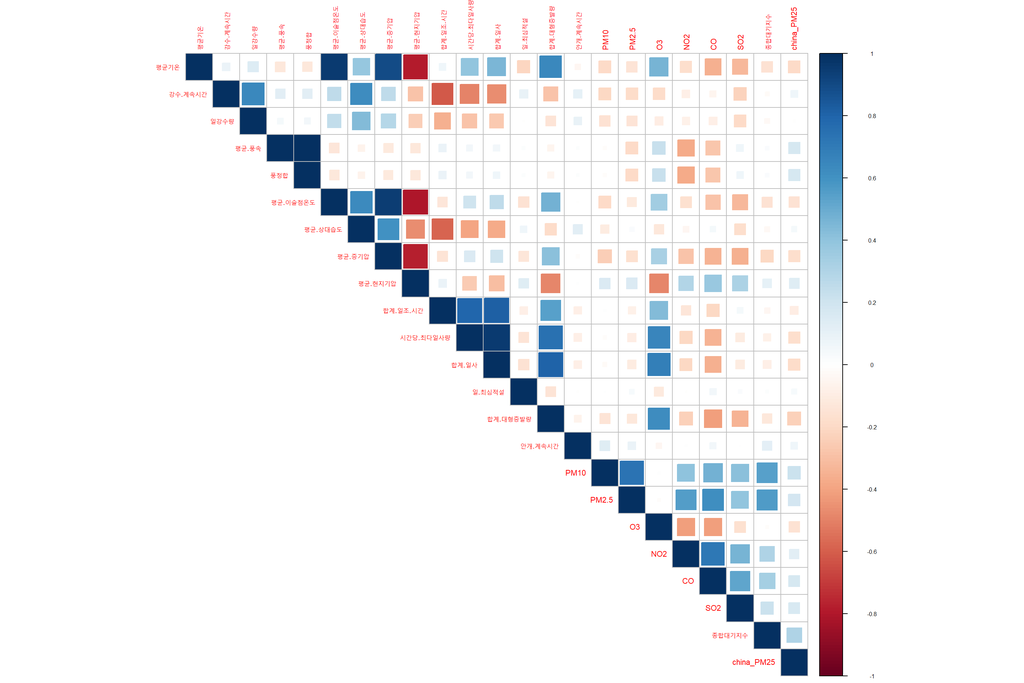

```r
analysis_data <- data.frame(weather2)
analysis_data$종합대기지수 <- lag(analysis_data$종합대기지수)
analysis_data$china_PM25 <- lag(analysis_data$china_PM25)
analysis_data <- analysis_data[-1,]

colvec2  <- c("평균기온", "강수.계속시간", "일강수량", "평균.풍속", "풍정합", "평균.이슬점온도", "평균.상대습도", "평균.증기압",
              "평균.현지기압", "합계.일조.시간","시간당.최다일사량", "합계.일사", "일.최심적설", "합계.대형증발량", "안개.계속시간",
              "PM10", "PM2.5", "O3","NO2", "CO", "SO2", "종합대기지수", "china_PM25")

corr_data <- cor(analysis_data[,colvec2])
corrplot(corr_data, method= "square", type="upper", tl.cex = 0.7, cl.cex = 0.5)
```

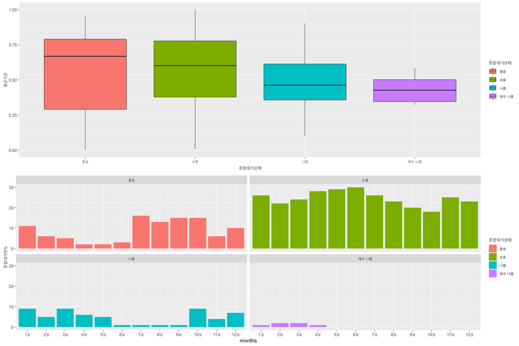

```r
p1<- analysis_data %>% ggplot(aes(종합대기상태, 평균기온, fill=종합대기상태)) +
      geom_boxplot(position = position_dodge(width = 1), outlier.alpha = T)
p2 <- analysis_data %>% group_by(years, months, 종합대기상태) %>% summarise(종합대기빈도=n()) %>%
  ggplot(aes(x=months, y=종합대기빈도, fill=종합대기상태)) + geom_bar(stat="identity", position = position_dodge(width = 1)) +
  facet_wrap(종합대기상태~.)

grid.arrange(p1, p2, nrow=2)
```

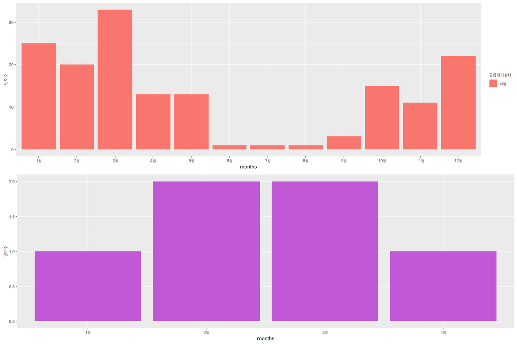

```r
summary_cai <- analysis_data %>% group_by(years, months, 종합대기상태) %>% summarise(빈도수=n())
p3 <- summary_cai[which(summary_cai$종합대기상태 == "나쁨"),] %>%
  ggplot(aes(x=months, y=빈도수, fill=종합대기상태)) + geom_bar(stat="identity")

p4 <- summary_cai[which(summary_cai$종합대기상태 == "매우 나쁨"),] %>%
  ggplot(aes(x=months, y=빈도수)) + geom_bar(stat="identity", fill='#c159d6')
grid.arrange(p3, p4, nrow=2)
```

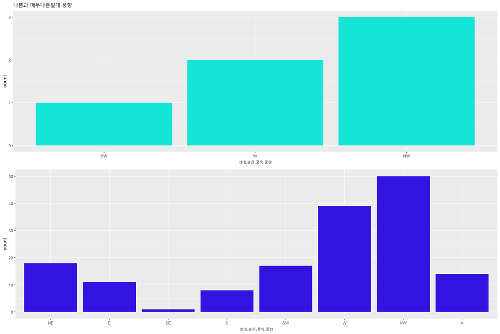

```r
group_direction3 <- analysis_data %>% group_by(years, months, 최대.순간.풍속.풍향, 종합대기상태) %>% summarise(count = n())
group_direction3 <- as.data.frame(group_direction3)

group_direction4 <- analysis_data %>% group_by(years, months,최대.풍속.풍향, 종합대기상태) %>% summarise(count = n())
group_direction4 <- as.data.frame(group_direction4)

p5 <- group_direction3 %>% ggplot(aes(x=최대.순간.풍속.풍향, y=count, fill=종합대기상태)) + geom_bar(stat="identity") + facet_wrap(종합대기상태~.)
p6 <- group_direction3[which(group_direction3$종합대기상태 == "매우 나쁨"),] %>%
  ggplot(aes(x=최대.순간.풍속.풍향, y=count)) +
  geom_bar(stat="identity", fill='#14e5d7')+
  ggtitle("나쁨과 매우나쁨일대 풍향")
p7 <- group_direction3[which(group_direction3$종합대기상태 == "나쁨"),] %>%
  ggplot(aes(x=최대.순간.풍속.풍향, y=count)) +
  geom_bar(stat="identity", fill='#3214e0')
grid.arrange(p6, p7, nrow=2)
```

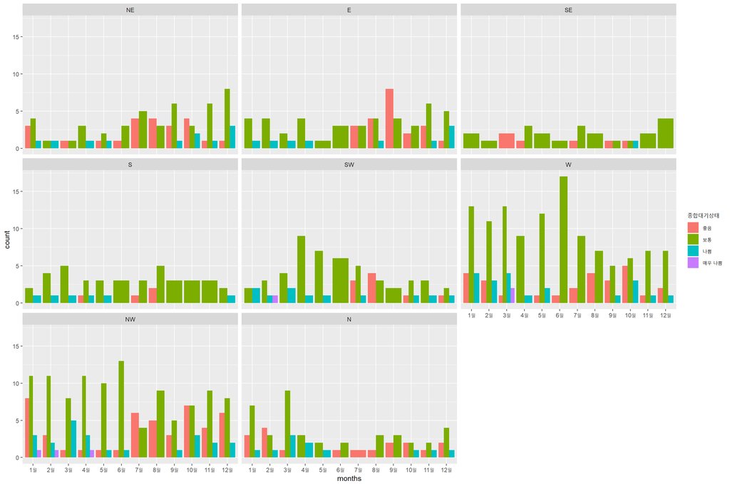

```r
p7 <- group_direction3 %>% ggplot(aes(x=months, y=count, fill=종합대기상태)) + geom_bar(stat="identity",position = "dodge") + facet_wrap(최대.순간.풍속.풍향~.)
p7
```

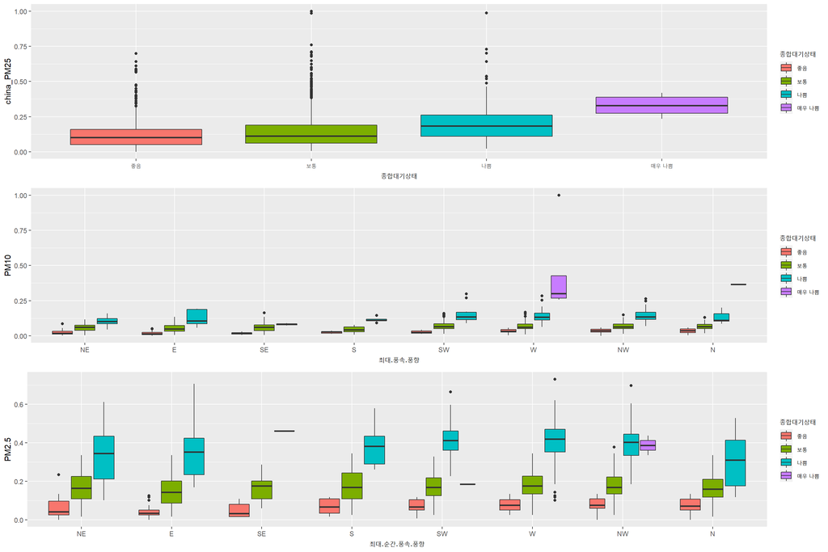

```r
p8 <- analysis_data %>% ggplot(aes(종합대기상태, china_PM25,  fill=종합대기상태)) + geom_boxplot(show.legend = T)
p9 <- analysis_data[-which(analysis_data$PM10 >= 0.75),] %>% ggplot(aes(최대.풍속.풍향, PM10,  fill=종합대기상태)) + geom_boxplot(outlier.alpha = T)
p9 <- analysis_data %>% ggplot(aes(최대.풍속.풍향, PM10,  fill=종합대기상태)) + geom_boxplot()
p10 <- analysis_data[-which(analysis_data$PM2.5 >= 0.75),] %>% ggplot(aes(최대.순간.풍속.풍향, PM2.5,  fill=종합대기상태)) + geom_boxplot()
grid.arrange(p8, p9, p10, ncol=1)
```

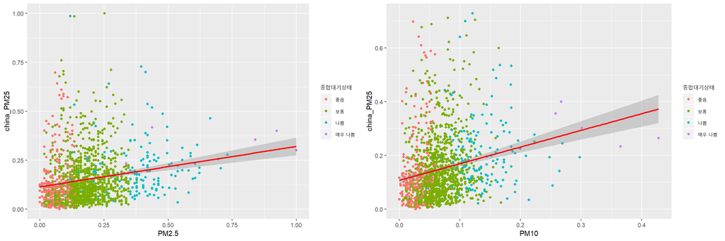

```r
p11<- analysis_data %>% ggplot(aes(PM2.5, china_PM25, col=종합대기상태)) +
  geom_point() + stat_smooth(method = lm, se = TRUE, color = "red")

p12 <- analysis_data[-which(analysis_data$PM10 >= 0.75|analysis_data$china_PM25 >= 0.75),] %>% ggplot(aes(PM10, china_PM25, col=종합대기상태)) +
  geom_point() + stat_smooth(method = lm, se = TRUE, color = "red")
grid.arrange(p11, p12, ncol=2)
```

```r
levels(analysis_data$종합대기상태) <- c("좋음","보통","나쁨","나쁨")
levels(analysis_data$종합대기상태)
```

```
## [1] "좋음" "보통" "나쁨"
```

## 4. Data Analysis

### 나이브 베이즈 분류기

- 베이즈 정리는 간단하게 아래와 같이 나타내어 질 수 있다.

$$P(C|X) = \frac{P(X \cap C\ )}{P(X)} = \frac{P(X|C)\ P(C) }{P(X)}$$

- Naive Bayse 분류는 feature들의 독립성을 가정하고 있기 때문에 아래의 조건부 확률이 확률들의 곱으로 나타내어 질 수 있다.

$$P(X^{1}_j, X^{2}_j, X^{3}_j, \cdots |C) = \prod_{k} P(x^{k}_j = a^k|C_i)$$

- 이를 이용하여 아래의 식을 최대로 만드는 class를 선택하는 방식으로 분류를 한다.

$$P(C_i)\prod_{k} P(x^{k}_j = a^k|C_i)$$

- 분석을 위해서 데이터 셋을 7대 3으로 분할

```r
analysis_data$index <- seq(2,(dim(analysis_data)[1]+1))
set.seed(1234)
analysis_data2 <- data.frame(analysis_data)
rownames(analysis_data2) <- analysis_data2$date
analysis_data2 <- analysis_data2[,-1]
train <- sample_frac(analysis_data2, 0.7)
train_idx <- as.vector(train$index)
test <- analysis_data2[-train_idx, ]
real_val <- test$종합대기상태
test <- dplyr::select(test, -c("종합대기상태"))
```

- 일단 가장 기본적인 모형으로 분석

```r
raw_model <- naiveBayes(종합대기상태~., data=train)
pred <- predict(raw_model, test)
confusionMatrix(pred, real_val)
```

```
## Confusion Matrix and Statistics
##
##           Reference
## Prediction 좋음 보통 나쁨
##       좋음   73   41    0
##       보통    9  251    8
##       나쁨    1   36   42
##
## Overall Statistics
##
##                Accuracy : 0.7939
##                  95% CI : (0.7541, 0.8299)
##     No Information Rate : 0.7115
##     P-Value [Acc > NIR] : 3.514e-05
##
##                   Kappa : 0.6062
##
##  Mcnemar's Test P-Value : 1.501e-08
##
## Statistics by Class:
##
##                      Class: 좋음 Class: 보통 Class: 나쁨
## Sensitivity               0.8795      0.7652     0.84000
## Specificity               0.8915      0.8722     0.90998
## Pos Pred Value            0.6404      0.9366     0.53165
## Neg Pred Value            0.9712      0.6010     0.97906
## Prevalence                0.1800      0.7115     0.10846
## Detection Rate            0.1584      0.5445     0.09111
## Detection Prevalence      0.2473      0.5813     0.17137
## Balanced Accuracy         0.8855      0.8187     0.87499
```

- 서로 상관성이 큰 변수들을 제거하고 다시 분석

```r
colnames(train)
```

```
##  [1] "평균기온"            "최저기온"            "최고기온"
##  [4] "강수.계속시간"       "일강수량"            "최대.순간.풍속"
##  [7] "최대.순간.풍속.풍향" "최대.풍속"           "최대.풍속.풍향"
## [10] "평균.풍속"           "풍정합"              "평균.이슬점온도"
## [13] "최소.상대습도"       "평균.상대습도"       "평균.증기압"
## [16] "평균.현지기압"       "합계.일조.시간"      "시간당.최다일사량"
## [19] "합계.일사"           "일.최심적설"         "합계.대형증발량"
## [22] "안개.계속시간"       "PM10"                "PM2.5"
## [25] "O3"                  "NO2"                 "CO"
## [28] "SO2"                 "종합대기상태"        "종합대기지수"
## [31] "주오염물질"          "china_PM25"          "months"
## [34] "years"               "index"
```

```r
train1 <- train[,-c(2,3,6,7,8,13,18,30,33,34,35)]
test1 <- test[, -c(2,3,6,7,8,13,18,29,32,33,34)]
nb_model1 <- naiveBayes(종합대기상태~., data=train1)
pred1 <- predict(nb_model1, test1)
confusionMatrix(pred1, real_val)
```

```
## Confusion Matrix and Statistics
##
##           Reference
## Prediction 좋음 보통 나쁨
##       좋음   71   40    0
##       보통   11  255    4
##       나쁨    1   33   46
##
## Overall Statistics
##
##                Accuracy : 0.8069
##                  95% CI : (0.7679, 0.842)
##     No Information Rate : 0.7115
##     P-Value [Acc > NIR] : 1.726e-06
##
##                   Kappa : 0.6295
##
##  Mcnemar's Test P-Value : 9.571e-09
##
## Statistics by Class:
##
##                      Class: 좋음 Class: 보통 Class: 나쁨
## Sensitivity               0.8554      0.7774     0.92000
## Specificity               0.8942      0.8872     0.91727
## Pos Pred Value            0.6396      0.9444     0.57500
## Neg Pred Value            0.9657      0.6178     0.98950
## Prevalence                0.1800      0.7115     0.10846
## Detection Rate            0.1540      0.5531     0.09978
## Detection Prevalence      0.2408      0.5857     0.17354
## Balanced Accuracy         0.8748      0.8323     0.91864
```

#### 대기 오염 지수를 범주화

```r
analysis_data3 <- data.frame(analysis_data2)
china_grade <- cut(weather$china_PM25, breaks=c(0, 15, 25, 50, Inf), labels=c("good", "normal", "bad", "very bad"))
PM25_grade <- cut(weather$PM2.5, breaks=c(0, 15, 25, 50, Inf), labels=c("good", "normal", "bad", "very bad"))
PM10_grade <- cut(weather$PM10, breaks=c(0, 30, 50, 100, Inf), labels=c("good", "normal", "bad", "very bad"))

analysis_data3$china_PM25 <- china_grade[-1]
analysis_data3$PM10 <- PM10_grade[-1]
analysis_data3$PM2.5 <- PM25_grade[-1]
```

```r
train2 <- analysis_data3[train_idx, -c(2,3,6,7,8,13,18,30,33,34,35)]
test2<- analysis_data3[-train_idx, -c(2,3,6,7,8,13,18,30,33,34,35)]
test2 <- dplyr::select(test2, -c("종합대기상태"))
nb_model2 <- naiveBayes(종합대기상태~., data=train2)
pred2 <- predict(nb_model2, test2)
confusionMatrix(pred2, real_val)
```

```
## Confusion Matrix and Statistics
##
##           Reference
## Prediction 좋음 보통 나쁨
##       좋음   80   88    0
##       보통    3  196    8
##       나쁨    0   44   42
##
## Overall Statistics
##
##                Accuracy : 0.6898
##                  95% CI : (0.6454, 0.7318)
##     No Information Rate : 0.7115
##     P-Value [Acc > NIR] : 0.8596
##
##                   Kappa : 0.4784
##
##  Mcnemar's Test P-Value : NA
##
## Statistics by Class:
##
##                      Class: 좋음 Class: 보통 Class: 나쁨
## Sensitivity               0.9639      0.5976     0.84000
## Specificity               0.7672      0.9173     0.89294
## Pos Pred Value            0.4762      0.9469     0.48837
## Neg Pred Value            0.9898      0.4803     0.97867
## Prevalence                0.1800      0.7115     0.10846
## Detection Rate            0.1735      0.4252     0.09111
## Detection Prevalence      0.3644      0.4490     0.18655
## Balanced Accuracy         0.8655      0.7574     0.86647
```

#### laplace smoothing

```r
nb_laplace_model <- naiveBayes(종합대기상태~., data=train1, laplace=0.1)
pred3 <- predict(nb_laplace_model, test1)
confusionMatrix(pred3, real_val)
```

```
## Confusion Matrix and Statistics
##
##           Reference
## Prediction 좋음 보통 나쁨
##       좋음   72   40    0
##       보통   10  255    4
##       나쁨    1   33   46
##
## Overall Statistics
##
##                Accuracy : 0.8091
##                  95% CI : (0.7702, 0.844)
##     No Information Rate : 0.7115
##     P-Value [Acc > NIR] : 9.972e-07
##
##                   Kappa : 0.6345
##
##  Mcnemar's Test P-Value : 4.579e-09
##
## Statistics by Class:
##
##                      Class: 좋음 Class: 보통 Class: 나쁨
## Sensitivity               0.8675      0.7774     0.92000
## Specificity               0.8942      0.8947     0.91727
## Pos Pred Value            0.6429      0.9480     0.57500
## Neg Pred Value            0.9685      0.6198     0.98950
## Prevalence                0.1800      0.7115     0.10846
## Detection Rate            0.1562      0.5531     0.09978
## Detection Prevalence      0.2430      0.5835     0.17354
## Balanced Accuracy         0.8808      0.8361     0.91864
```

### Multinomial Logistics

```r
ml_model <- multinom(종합대기상태~., data=train1, trace=F)
pred4 <- predict(ml_model, test1)
confusionMatrix(pred4, real_val)
```

```
## Confusion Matrix and Statistics
##
##           Reference
## Prediction 좋음 보통 나쁨
##       좋음   57   19    0
##       보통   26  308    7
##       나쁨    0    1   43
##
## Overall Statistics
##
##                Accuracy : 0.885
##                  95% CI : (0.8523, 0.9127)
##     No Information Rate : 0.7115
##     P-Value [Acc > NIR] : < 2.2e-16
##
##                   Kappa : 0.7349
##
##  Mcnemar's Test P-Value : NA
##
## Statistics by Class:
##
##                      Class: 좋음 Class: 보통 Class: 나쁨
## Sensitivity               0.6867      0.9390     0.86000
## Specificity               0.9497      0.7519     0.99757
## Pos Pred Value            0.7500      0.9032     0.97727
## Neg Pred Value            0.9325      0.8333     0.98321
## Prevalence                0.1800      0.7115     0.10846
## Detection Rate            0.1236      0.6681     0.09328
## Detection Prevalence      0.1649      0.7397     0.09544
## Balanced Accuracy         0.8182      0.8455     0.92878
```

### DNN

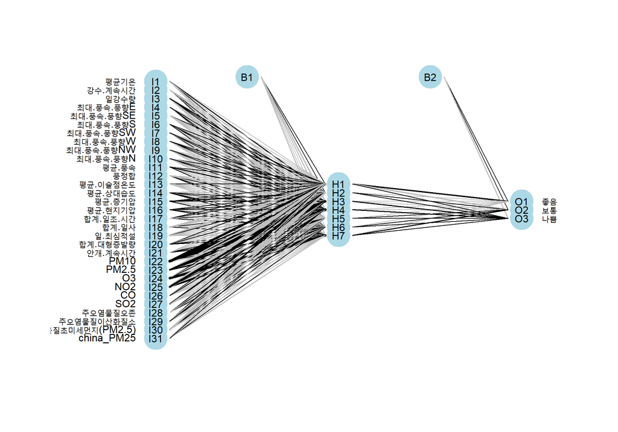

```r
set.seed(1234)
dnn_model <- nnet(종합대기상태~., data = train1, size=7, maxit=1000, trace=F)
plot.nnet(dnn_model)
```

```r
pred5 <- predict(dnn_model, test1, type="class")
confusionMatrix(factor(pred5, levels = c("좋음","보통","나쁨")), real_val)
```

```
## Confusion Matrix and Statistics
##
##           Reference
## Prediction 좋음 보통 나쁨
##       좋음   77    6    0
##       보통    6  317    1
##       나쁨    0    5   49
##
## Overall Statistics
##
##                Accuracy : 0.961
##                  95% CI : (0.939, 0.9767)
##     No Information Rate : 0.7115
##     P-Value [Acc > NIR] : < 2.2e-16
##
##                   Kappa : 0.9142
##
##  Mcnemar's Test P-Value : NA
##
## Statistics by Class:
##
##                      Class: 좋음 Class: 보통 Class: 나쁨
## Sensitivity               0.9277      0.9665      0.9800
## Specificity               0.9841      0.9474      0.9878
## Pos Pred Value            0.9277      0.9784      0.9074
## Neg Pred Value            0.9841      0.9197      0.9975
## Prevalence                0.1800      0.7115      0.1085
## Detection Rate            0.1670      0.6876      0.1063
## Detection Prevalence      0.1800      0.7028      0.1171
## Balanced Accuracy         0.9559      0.9569      0.9839
```

### 교차검증

```r
cv_allmodel <- function(x, y){
  set.seed(1234)
  folds <- createFolds(analysis_data2$종합대기상태, k=x)
  nb_acc <- c()
  mn_acc <- c()
  nn_acc <- c()
    for (f in folds) {
    train_cv <- analysis_data2[-f,]
    test_cv <- analysis_data2[f, ]
    cv.real_val <- test_cv$종합대기상태
    test_cv <- dplyr::select(test_cv, -c("종합대기상태"))
    cv.nb_model <- naiveBayes(종합대기상태~., data=train_cv, laplace=1)
    cv.mn_model <- multinom(종합대기상태~., data=train_cv, trace=F)
    cv.nn_model <- nnet(종합대기상태~., data = train_cv, size=y, maxit=1000, trace=F)
    cv.pred_nb <- predict(cv.nb_model, test_cv, type="class")
    cv.pred_mn <- predict(cv.mn_model, test_cv, type="class")
    cv.pred_nn <- predict(cv.nn_model, test_cv, type="class")
    nb_f_acc <- sum(cv.pred_nb==cv.real_val)/NROW(cv.real_val)
    mn_f_acc <- sum(cv.pred_mn==cv.real_val)/NROW(cv.real_val)
    nn_f_acc <- sum(cv.pred_nn==cv.real_val)/NROW(cv.real_val)
    nb_acc <-append(nb_acc, nb_f_acc)
    mn_acc <-append(mn_acc, mn_f_acc)
    nn_acc <-append(nn_acc, nn_f_acc)
    }
  cv.df <- data.frame(
    k = seq(1,x),
    naive_Bayes = nb_acc,
    multinomial = mn_acc,
    neuralnet = nn_acc
  )
  return(cv.df)
}

nb_cv_acc <- cv_allmodel(8,8)
nb_cv_acc
```

```
##   k naive_Bayes multinomial neuralnet
## 1 1   0.7343750   0.8697917 0.8229167
## 2 2   0.7591623   0.8691099 0.8429319
## 3 3   0.7291667   0.8958333 0.8593750
## 4 4   0.7604167   0.8125000 0.8802083
## 5 5   0.8031088   0.8911917 0.9015544
## 6 6   0.6994819   0.8238342 0.7720207
## 7 7   0.7552083   0.8489583 0.8281250
## 8 8   0.8020833   0.8593750 0.8645833
```

```r
mean_cv <- apply(nb_cv_acc,2,mean)
mean_cv
```

```
##           k naive_Bayes multinomial   neuralnet
##   4.5000000   0.7553754   0.8588243   0.8464644
```

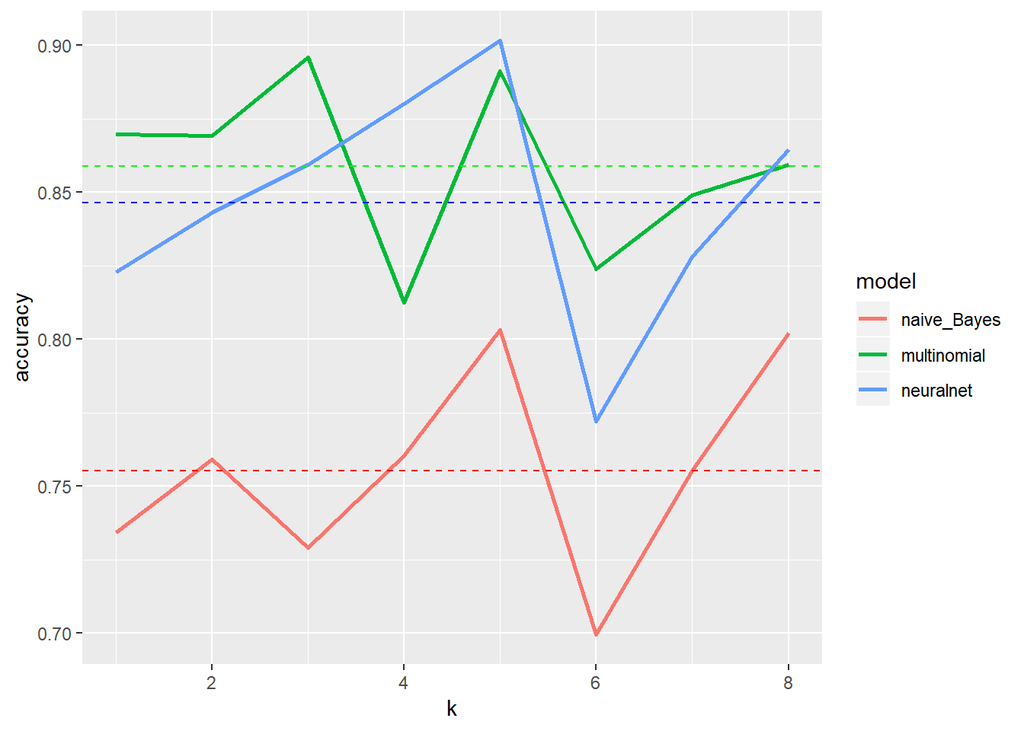

```r
nb_cv_acc %>% ggplot() +
  geom_line(aes(x=k, y=naive_Bayes, colour="darkblue"),size=1) +
  geom_line(aes(x=k, y=multinomial, colour="green"),size=1) +
  geom_line(aes(x=k, y=neuralnet, colour="red"),size=1) +
  scale_color_discrete(name = "model", labels = c("naive_Bayes", "multinomial", "neuralnet")) +
  geom_hline(yintercept=mean_cv[2], linetype="dashed", color = "red") +
  geom_hline(yintercept=mean_cv[3], linetype="dashed", color = "green") +
  geom_hline(yintercept=mean_cv[4], linetype="dashed", color = "blue") +
  ylab("accuracy")
```

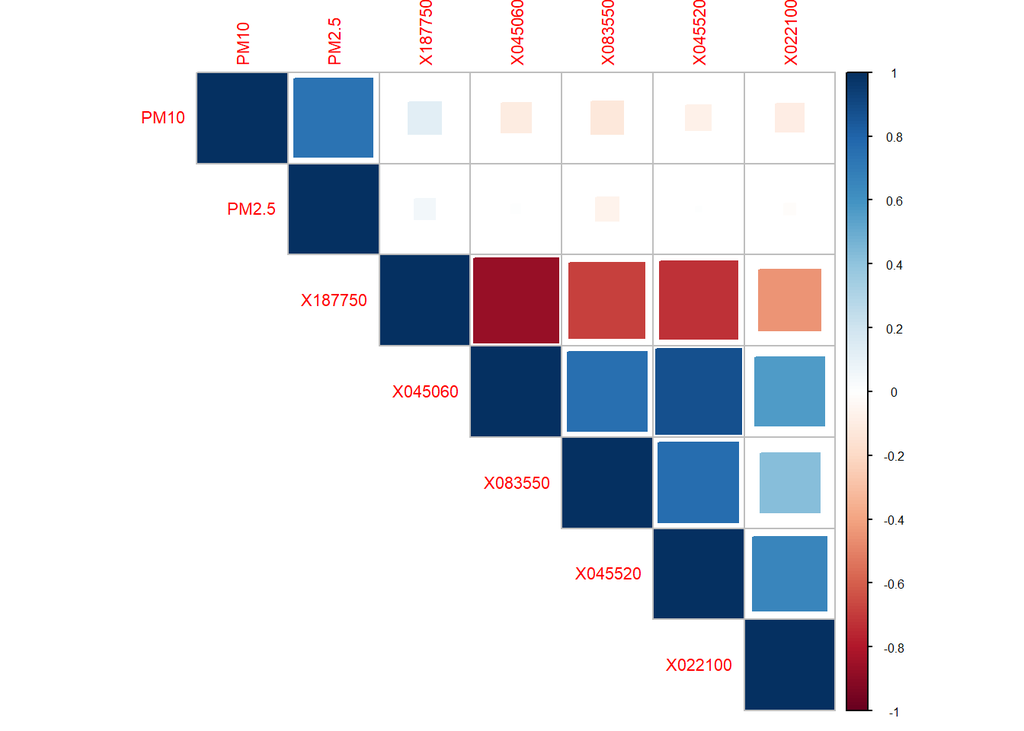

```r
zscale <- function(x) {
  (x-mean(x))/sd(x)
}

stock_corr <- cor(stocks[,-c(1)])
corrplot(stock_corr, method= "square", type="upper", tl.cex = 0.7, cl.cex = 0.5)
```

```r
stock_ts <- ts(stocks, start=c(2015,1,1), frequency =12)
stock_ts <- 1+(stock_ts/stats::lag(stock_ts,-1) - 1)
stock_ts <- data.frame(stock_ts)
stock_ts$date <- stocks$date[2:1538]
stock_ts <- stock_ts[,-c(1)]
colnames(stock_ts)
```

```
## [1] "stock_ts.PM10"    "stock_ts.PM2.5"   "stock_ts.X187750"
## [4] "stock_ts.X045060" "stock_ts.X083550" "stock_ts.X045520"
## [7] "stock_ts.X022100" "date"
```

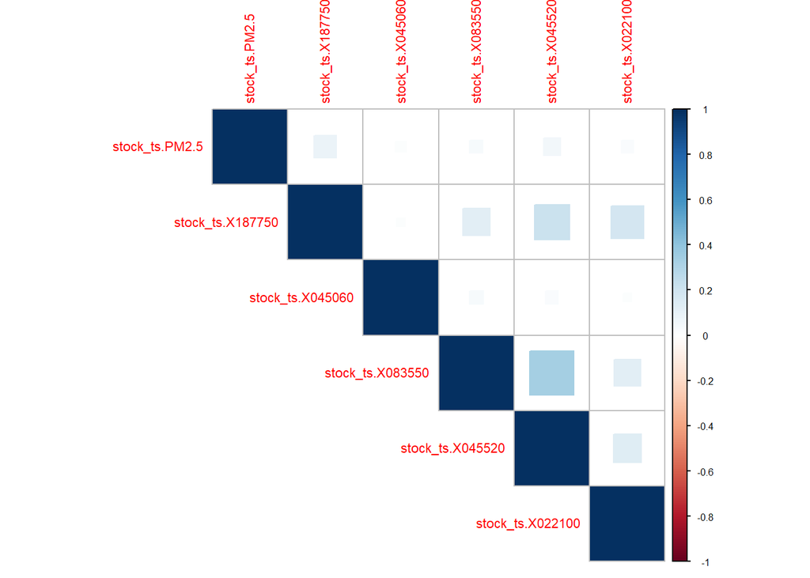

```r
stock_ts_corr <- cor(stock_ts[,-c(1,8)])
corrplot(stock_ts_corr, method= "square", type="upper", tl.cex = 0.7, cl.cex = 0.5)
```

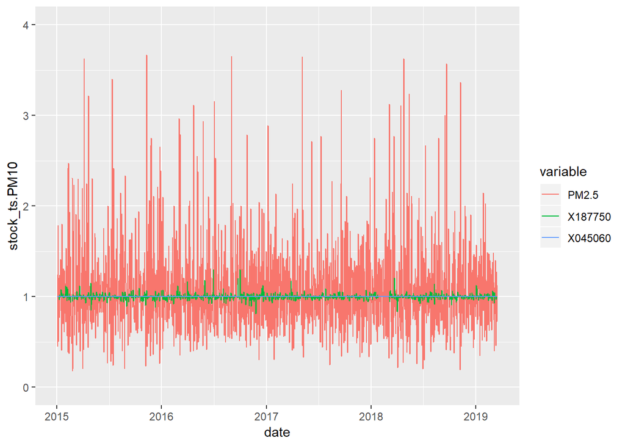

```r
# "stock_ts.PM10"    "stock_ts.PM2.5"   "stock_ts.X187750" "stock_ts.X045060" "stock_ts.X083550" "stock_ts.X045520" "stock_ts.X022100"
stock_ts %>% ggplot(aes(x=date))+
  geom_line(aes(y=stock_ts.PM10,colour="darkblue"))+
  geom_line(aes(y=stock_ts.X187750, colour="green"))+
  geom_line(aes(y=stock_ts.X045060, colour="red"))+
  scale_color_discrete(name = "variable",
                       labels = c("PM2.5", "X187750", "X045060"))+
  ylim(c(-0,4))
```

```r
#"X187750", "X045060", "X083550", "X045520", "X022100"
```